# Applied Machine Learning

In-class exercise 03-1

# Goal

Learn how to do preprocessing steps directly on a mlr3 `Task` object and how to combine a preprocessing with a learner to create a simple linear ML pipeline that first applies the preprocessing and then trains a learner.

# German Credit Data

## Description

- Data from 1973 to 1975 from a large regional bank in southern Germany classifying credits described by a set of attributes to good or bad credit risks.
- Stratified sample of 1000 credits (300 bad ones and 700 good ones).
- Customers with good credit risks perfectly complied with the conditions of the contract while customers with bad credit risks did not comply with the contract as required.
- Available in `tsk("german_credit")`.

## Data Dictionary

n = 1,000 observations of credits

- `credit_risk`: Has the credit contract been complied with (good) or not (bad)?
- `age`: Age of debtor in years
- `amount`: Credit amount in DM
- `credit_history`: History of compliance with previous or concurrent credit contracts
- `duration`: Credit duration in months
- `employment_duration`: Duration of debtor’s employment with current employer
- `foreign_worker`: Whether the debtor is a foreign worker
- `housing`: Type of housing the debtor lives in
- `installment_rate`: Credit installments as a percentage of debtor’s disposable income
- `job`: Quality of debtor’s job
- `number_credits`: Number of credits including the current one the debtor has (or had) at this bank
- `other_debtors`: Whether there is another debtor or a guarantor for the credit
- `other_installment_plans`: Installment plans from providers other than the credit-giving bank
- `people_liable`: Number of persons who financially depend on the debtor
- `personal_status_sex`: Combined information on sex and marital status
- `present_residence`: Length of time (in years) the debtor lives in the present residence
- `property`: The debtor’s most valuable property
- `purpose`: Purpose for which the credit is needed
- `savings`: Debtor’s saving
- `status`: Status of the debtor’s checking account with the bank
- `telephone`: Whether there is a telephone landline registered on the debtor’s name

# Recap mlr3 Tasks

An `mlr3` `Task` encapsulates data with meta-information, such as the name of the target variable and the type of the learning problem (in our example this would be a **classification** task, where the target is a factor label with relatively few distinct values).

```r
library(mlr3)
task = tsk("german_credit")
print(task)
## <TaskClassif:german_credit> (1000 x 21): German Credit
## * Target: credit_risk
## * Properties: twoclass
## * Features (20):
##   - fct (14): credit_history, employment_duration, foreign_worker, housing, job, other_debtors,
##     other_installment_plans, people_liable, personal_status_sex, property, purpose, savings, status,
##     telephone
##   - int (3): age, amount, duration
##   - ord (3): installment_rate, number_credits, present_residence
```

The `print()` method gives a short summary of the task: It has 1000 observations and 21 columns of which 20 are features. 17 features are categorical (i.e., factors) and 3 features are integer.

By using the `$data()` method, we get access to the data (in the form of a `data.table`):

```r
str(task$data())
```

```
## Classes 'data.table' and 'data.frame':   1000 obs. of  21 variables:
##  $ credit_risk            : Factor w/ 2 levels "good","bad": 1 2 1 1 2 1 1 1 1 2 ...
##  $ age                    : int  67 22 49 45 53 35 53 35 61 28 ...
##  $ amount                 : int  1169 5951 2096 7882 4870 9055 2835 6948 3059 5234 ...
##  $ credit_history         : Factor w/ 5 levels "delay in paying off in the past",..: 5 3 5 3 4 3 3 3 3 5 ...
##  $ duration               : int  6 48 12 42 24 36 24 36 12 30 ...
##  $ employment_duration    : Factor w/ 5 levels "unemployed","< 1 yr",..: 5 3 4 4 3 3 5 3 4 1 ...
##  $ foreign_worker         : Factor w/ 2 levels "no","yes": 1 1 1 1 1 1 1 1 1 1 ...
##  $ housing                : Factor w/ 3 levels "for free","rent",..: 2 2 2 3 3 3 2 1 2 2 ...
##  $ installment_rate       : Ord.factor w/ 4 levels ">= 35"<"25 <= ... < 35"<..: 4 2 2 2 3 2 3 2 2 4 ...
##  $ job                    : Factor w/ 4 levels "unemployed/unskilled - non-resident",..: 3 3 2 3 3 2 3 4 2 4 ...
##  $ number_credits         : Ord.factor w/ 4 levels "1"<"2-3"<"4-5"<..: 2 1 1 1 2 1 1 1 1 2 ...
##  $ other_debtors          : Factor w/ 3 levels "none","co-applicant",..: 1 1 1 3 1 1 1 1 1 1 ...
##  $ other_installment_plans: Factor w/ 3 levels "bank","stores",..: 3 3 3 3 3 3 3 3 3 3 ...
##  $ people_liable          : Factor w/ 2 levels "0 to 2","3 or more": 1 1 2 2 2 2 1 1 1 1 ...
##  $ personal_status_sex    : Factor w/ 4 levels "male : divorced/separated",..: 3 2 3 3 3 3 3 3 1 4 ...
##  $ present_residence      : Ord.factor w/ 4 levels "< 1 yr"<"1 <= ... < 4 yrs"<..: 4 2 3 4 4 4 4 2 4 2 ...
##  $ property               : Factor w/ 4 levels "unknown / no property",..: 1 1 1 2 4 4 2 3 1 3 ...
##  $ purpose                : Factor w/ 11 levels "others","car (new)",..: 4 4 7 3 1 7 3 2 4 1 ...
##  $ savings                : Factor w/ 5 levels "unknown/no savings account",..: 5 1 1 1 1 5 3 1 4 1 ...
##  $ status                 : Factor w/ 4 levels "no checking account",..: 1 2 4 1 1 4 4 2 4 2 ...
##  $ telephone              : Factor w/ 2 levels "no","yes (under customer name)": 2 1 1 1 1 2 1 2 1 1 ...
##  - attr(*, ".internal.selfref")=<externalptr>
```

Note that a `mlr3` `Task` object comes with plenty of functionality in the form of fields, methods and active bindings, see `?Task`, e.g., to get a summary of all feature names, you can use:

```r
task$feature_names
```

```
##  [1] "age"                     "amount"                  "credit_history"          "duration"
##  [5] "employment_duration"     "foreign_worker"          "housing"                 "installment_rate"
##  [9] "job"                     "number_credits"          "other_debtors"           "other_installment_plans"
## [13] "people_liable"           "personal_status_sex"     "present_residence"       "property"
## [17] "purpose"                 "savings"                 "status"                  "telephone"
```

To obtain information about the types of features of the task (similarly like in the data dictionary above), we can inspect the active binding fields of the task object (see, `?Task`):

```r
task$feature_types
```

```
##                          id    type
##  1:                     age integer
##  2:                  amount integer
##  3:          credit_history  factor
##  4:                duration integer
##  5:     employment_duration  factor
##  6:          foreign_worker  factor
##  7:                 housing  factor
##  8:        installment_rate ordered
##  9:                     job  factor
## 10:          number_credits ordered
## 11:           other_debtors  factor
## 12: other_installment_plans  factor
## 13:           people_liable  factor
## 14:     personal_status_sex  factor
## 15:       present_residence ordered
## 16:                property  factor
## 17:                 purpose  factor
## 18:                 savings  factor
## 19:                  status  factor
## 20:               telephone  factor
```

# Exercises

## Exercise 1: Preprocess a Task (with One-Hot Encoding)

Use the one-hot encoding `PipeOp` to convert all categorical features from the `german_credit` task into a preprocessed task containing 0-1 indicator variables for each category level instead of categorical features.

**Hint 1:**

Load the `mlr3pipelines` package and get an overview of possible `PipeOp` that can be used for different preprocessing steps by printing `mlr_pipeops` or the first two columns of the corresponding table `as.data.table(mlr_pipeops)[,1:2]`. Look for a **factor encoding** and pass the corresponding `key` for factor encoding to the `po()` function (see also the help page `?PipeOpEncode`). Then, use the `$train()` method of the `PipeOp` object which expects a **list** containing the task to be converted as input and produces a **list** containing the converted task.

**Hint 2:**

```r
library(mlr3pipelines)
# Create a PipeOp object that applies one-hot encoding
poe = po(...)
# Apply a created PipeOp to e.g. preprocess an input
encoded_task = poe$train(input = ...)$output
str(...$data())
```

### Solution:

**Click me:**

```r
library(mlr3pipelines)
poe = po("encode", method = "one-hot")
# Use the $help() method to open a help page of any PipeOp object
# poe$help()
encoded_task = poe$train(input = list(task))$output
str(encoded_task$data())
```

```
## Classes 'data.table' and 'data.frame':   1000 obs. of  73 variables:
##  $ credit_risk                                               : Factor w/ 2 levels "good","bad": 1 2 1 1 2 1 1 1 1 2 ...
##  $ age                                                       : int  67 22 49 45 53 35 53 35 61 28 ...
##  $ amount                                                    : int  1169 5951 2096 7882 4870 9055 2835 6948 3059 5234 ...
##  $ duration                                                  : int  6 48 12 42 24 36 24 36 12 30 ...
##  $ credit_history.delay.in.paying.off.in.the.past            : num  0 0 0 0 0 0 0 0 0 0 ...
##  $ credit_history.critical.account.other.credits.elsewhere   : num  0 0 0 0 0 0 0 0 0 0 ...
##  $ credit_history.no.credits.taken.all.credits.paid.back.duly: num  0 1 0 1 0 1 1 1 1 0 ...
##  $ credit_history.existing.credits.paid.back.duly.till.now   : num  0 0 0 0 1 0 0 0 0 0 ...
##  $ credit_history.all.credits.at.this.bank.paid.back.duly    : num  1 0 1 0 0 0 0 0 0 1 ...
##  $ employment_duration.unemployed                            : num  0 0 0 0 0 0 0 0 0 1 ...
##  $ employment_duration...1.yr                                : num  0 0 0 0 0 0 0 0 0 0 ...
##  $ employment_duration.1..........4.yrs                      : num  0 1 0 0 1 1 0 1 0 0 ...
##  $ employment_duration.4..........7.yrs                      : num  0 0 1 1 0 0 0 0 1 0 ...
##  $ employment_duration....7.yrs                              : num  1 0 0 0 0 0 1 0 0 0 ...
```

[output cut: 60 more lines]

## Exercise 2: Create a Simple ML Pipeline (with One-Hot Encoding)

Some learners cannot handle categorical features such as the the `xgboost` learner (which gives an error message when applied to a task containing categorical features):

```r
library(mlr3verse)
lrnxg = lrn("classif.xgboost")
lrnxg$train(task)
```

```
## Error: <TaskClassif:german_credit> has the following unsupported feature types: factor, ordered
```

```r
lrnxg$predict(task)
```

```
## Error: <TaskClassif:german_credit> has the following unsupported feature types: factor, ordered
```

Combine the `xgboost` learner with a preprocessing step that applies one-hot encoding to create a ML pipeline that first converts all categorical features to 0-1 indicator variables and then applies the `xgboost` learner. Train the ML pipeline on the `german_credit` task and make predictions on the training data.

**Hint 1:**

You can create a `Graph` that combines a `PipeOp` object with a learner object (or further `PipeOp` objects) by concatenating them using the `%>>%` operator. The `Graph` contains all information of a sequential ML pipeline. Convert the `Graph` into a `GraphLearner` to be able to run the whole ML pipeline like a usual learner object with which we can train, predict, resample, and benchmark the `GraphLearner` as we have learned. See also the help page `?GraphLearner`.

**Hint 2:**

```r
library(mlr3verse)
lrnxg = lrn("classif.xgboost")
poe = po(...)
graph = ...

glrn = as_learner(...)
...$train(...)
...$predict(...)
```

### Solution:

**Click me:**

```r
library(mlr3verse)
lrnxg = lrn("classif.xgboost")
poe = po("encode", method = "one-hot")
graph = poe %>>% lrnxg

glrn = as_learner(graph) # Alternative: glrn = GraphLearner$new(graph)
glrn$train(task)
glrn$predict(task)
## <PredictionClassif> for 1000 observations:
##     row_ids truth response
##           1  good     good
##           2   bad      bad
##           3  good     good
## ---
##         998  good     good
##         999   bad      bad
##        1000  good     good
```

## Exercise 3: Feature Transformation for Decision Trees

The structure of a decision tree is insensitive to monotonic transformations of the features (and scaling is a monotonic transformation). This means that although the scaled features are different to non-scaled features, the decision tree will have the same structure (the values of the split points for numeric feature might be different as the numeric features will have a different scale, but the structure of the decision tree will stay the same).

Do the following tasks:

1. Use the `PipeOp` to scale all numeric features from the `german_credit` task and create a preprocessed task the scaled numeric features. Do this for standard scaling (i.e. normalization by centering and scaling) and for box-cox transformation. You can look up the corresponding keys by inspecting the table `as.data.table(mlr_pipeops)[,1:2]`. Create the preprocessed tasks `task_scaled` and `task_boxcox` and check the values of the numeric features. You may have to first install the `bestNormalize` package for the boxcox transformation.

**Hint for task 1:**

Proceed as in Exercise 1, but use `scale` and `boxcox` instead of `encode` as keys in the `po()` function. If installing the `bestNormalize` package does not work, you can also select a different scaling approach such as `scalemaxabs` or `scalerange`.

2. Create two ML pipelines, one that combines the `classif.rpart` learner with the standard scaling and another one that combines `classif.rpart` learner with the boxcox scaling. Then use the `classif.rpart` learner and the two ML pipelines on the `german_credit` task to fit 3 different decision trees (one trained on the raw task and the other two trained on the scaled and box-cox transformed task). Visualize the decision tree structure using the `rpart.plot` function from the `rpart.plot` package.

**Hint for task 2:**

Proceed as in Exercise 2 to create two `GraphLearner`s, one with `po("scale")` and the other one with `po("boxcox")`. Then, train the `classif.rpart` learner and the two `GraphLearner`s on the `german_credit` task. Apply the `rpart.plot` function to the trained model objects to compare the structure of the decision trees. Note: While for the `classif.rpart` learner, the model object is directly contained in the `$model` slot of the learner after training, the `$model` slot of the two `GraphLearners` is a list and you have to access the trained model via `$model$classif.rpart$model`.

### Solution:

**Click me:**

1. Solution of first task:

```r
library(mlr3pipelines)
pos = po("scale")
pobc = po("boxcox")

numfeat = task$feature_types$id[task$feature_types$type == "integer"]
task_scaled = pos$train(list(task))$output
task_scaled$data(cols = numfeat)
```

```
##              age     amount   duration
##    1:  2.7650729 -0.7447588 -1.2358595
##    2: -1.1908081  0.9493418  2.2470700
##    3:  1.1827205 -0.4163541 -0.7382981
##    4:  0.8310866  1.6334296  1.7495086
##    5:  1.5343544  0.5663801  0.2568246
##   ---
##  996: -0.3996319 -0.5438899 -0.7382981
##  997:  0.3915443  0.2075085  0.7543859
##  998:  0.2157274 -0.8740659 -0.7382981
##  999: -1.1028996 -0.5052749  1.9982893
## 1000: -0.7512658  0.4622259  1.9982893
```

```r
task_boxcox = pobc$train(list(task))$output
task_boxcox$data(cols = numfeat)
```

```
##              age     amount   duration
##    1:  1.9655985 -0.9321351 -1.8030770
##    2: -1.6083289  1.1561636  1.7649534
##    3:  1.2099199 -0.1577607 -0.6895020
##    4:  0.9758211  1.4952618  1.5145291
##    5:  1.4143199  0.9105163  0.4981968
##   ---
##  996: -0.2181809 -0.4045337 -0.6895020
##  997:  0.6296197  0.6207575  0.8971263
##  998:  0.4702539 -1.4439956 -0.6895020
##  999: -1.4099472 -0.3244646  1.6435299
## 1000: -0.7407356  0.8335695  1.6435299
```

2. Solution of second task showing that the decision tree strucuture is exactly the same (although the split points of the numeric features such as `amount` and `duration` are different due to the transformed features):

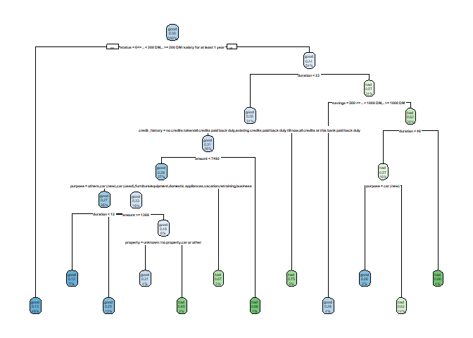

```r
library(mlr3pipelines)
rp = lrn("classif.rpart")
rpscale = as_learner(pos %>>% rp)
rpboxcox = as_learner(pobc %>>% rp)

rp$train(task)
rpscale$train(task)
rpboxcox$train(task)

library(rpart.plot)
rpart.plot(rp$model)
```

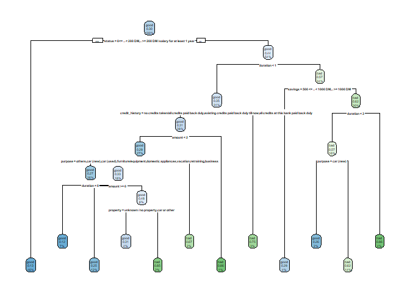

```r
rpart.plot(rpscale$model$classif.rpart$model)
```

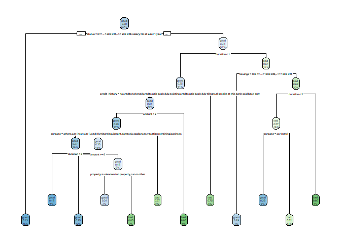

```r
rpart.plot(rpboxcox$model$classif.rpart$model)
```

```r
# Alternative solution using the transformed tasks:
rp = lrn("classif.rpart")

library(rpart.plot)
rp$train(task)
rpart.plot(rp$model)

rp$train(task_scaled)
rpart.plot(rp$model)

rp$train(task_boxcox)
rpart.plot(rp$model)
```

## Exercise 4: Benchmark k-NN and Decison Tree with Scaling and Box-Cox Transformation

In the previous exercise we saw that scaling does not affect a decision tree structure. That is scaling numeric features of a decision tree will not have any (strong) effect on the performance. However, for some learners, scaling numeric features is important, especially if they are based on computing distances such as the k-NN learner (because scaling will convert all numeric features into a comparable scale).

In this exercise we want to conduct a benchmark that illustrates these claims. Consider the k-NN learner without scaling `lrn("classif.kknn", scale = FALSE)` and the decision tree `lrn("classif.rpart")`. Combine these two learners once with `po("scale")` (for normalization, i.e., substracting the mean and dividing by the standard deviation) and once with `po("boxcox")` for box-cox transformation of the numeric features. Then, setup a benchmark to compare their performance (including the non-scaled k-NN `lrn("classif.kknn", scale = FALSE)` and decision tree `lrn("classif.rpart")`) using 10-fold cross-validation. In total, you will benchmark 6 learners, the 4 ML pipelines and the 2 learners. For reproducibility, use the seed `set.seed(2023)`.

**Hint:**

```r
library(mlr3pipelines)

set.seed(2023)
lrns = list(
  lrn("classif.kknn", scale = FALSE),
  po("scale") %>>% ...,
  po("boxcox") %>>% ..,
  lrn("classif.rpart"),
  ... %>>% lrn(...),
  ... %>>% ...
)

design = benchmark_grid(...)
bmr = benchmark(...)
bmr$aggregate()
autoplot(bmr)
```

### Solution:

**Click me:**

```r
library(mlr3pipelines)
pos = po("scale")
pobc = po("boxcox")

set.seed(2023)
lrns = list(
  lrn("classif.kknn", scale = FALSE, predict_type = "prob"),
  pos %>>% lrn("classif.kknn", scale = FALSE, predict_type = "prob"),
  pobc %>>% lrn("classif.kknn", scale = FALSE, predict_type = "prob"),
  lrn("classif.rpart", predict_type = "prob"),
  pos %>>% lrn("classif.rpart", predict_type = "prob"),
  pobc %>>% lrn("classif.rpart", predict_type = "prob")
)

cv = rsmp("cv", folds = 10)
design = benchmark_grid(list(task), lrns, cv)
bmr = benchmark(design)
bmr$aggregate(msr("classif.bbrier"))
```

```
##    nr       task_id           learner_id resampling_id iters classif.bbrier
## 1:  1 german_credit         classif.kknn            cv    10      0.2455572
## 2:  2 german_credit   scale.classif.kknn            cv    10      0.2008901
## 3:  3 german_credit  boxcox.classif.kknn            cv    10      0.2000929
## 4:  4 german_credit        classif.rpart            cv    10      0.1911524
## 5:  5 german_credit  scale.classif.rpart            cv    10      0.1912358
## 6:  6 german_credit boxcox.classif.rpart            cv    10      0.1912358
## Hidden columns: resample_result
```

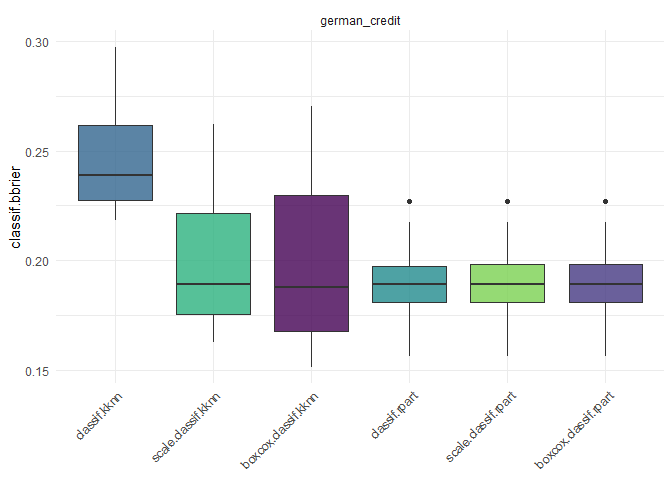

```r
autoplot(bmr, measure = msr("classif.bbrier"))
```

# Summary

We learned how to apply preprocessing steps such as factor encoding or scaling directly on a task. Furthermore, we have also seen how to create a `GraphLearner` which applies a ML pipeline on a task that first does all preprocessing steps defined in the `Graph` and then trains a learner on the preprocessed task. We also saw that scaling is important for the k-NN learner but not for a decision tree as neither the decision tree structure nor the performance of the decision tree changes.